# Genotyping Post-imputation report

Darren Cameron

2026-03-17

## Genotyping post-imputation QC steps

- From workflow dir run `mkdir -p ../results/04GENOTYPES-POST/TOPMED/`. Copy imputed output file into that dircetory
1. `impute_check`: Evaluate imputation quality for each chromosome
2. `impute_check_cat`: Cat impute check counts for each chr into single file
3. `dwnld_dbsnp_ref`: Download dbSNP reference
4. `add_rsID`: Add dbSNP rsIDs to each imputed chr-specific VCF file
5. `vcf_cat`: Cat imputed chr-specific VCF files into single file
6. `filter_tags`: Compute HWE and filt cated VCF; Keep SNPs pass MAF, R^2 and HWE limits
   - HWE: <0.0001
   - MAF < 0.05
   - R^2 < 0.8
7. `check_VCF`: Validate the filt VCF against ref genome and ID problematic SNPs
8. `exclude_SNPs`: Exclude SNPs IDed in CheckVCF
9. `idx_vcf`: Index the final filtered VCF
10. `create_combined_log`: Summarise logs from previous rules
11. `get_sample_list`: Extract final sample list
12. `vcf_to_plink`: Convert genotypes VCF to plink format
13. `get_ld_pruned_snps`: LD prune SNPs before running PCA on genotypes
    - `--indep-pairwise 250 5 0.2`
14. `prune_genotypes`: Create genotypes plink-format file containing only pruned SNPs
15. `calc_genotype_pcs`: Run PCA on pruned genotypes to get genotype-specific PC covariates

### Check imputation

Imputation Quality Summary by Chromosome

Metrics include SNP counts, MAF, and R² thresholds<sup>1</sup>

| Chromosome | Total SNPs | MAF < 0.05 | MAF ≥ 0.05 | R² < 0.8 | R² ≥ 0.8 | MAF ≥ 0.05 & R² ≥ 0.8 |
| --- | --- | --- | --- | --- | --- | --- |
| 1 | 1,547,091 | 1,083,591 | 463,500 | 170,155 | 1,376,936 | 459,613 |
| 2 | 1,662,989 | 1,163,938 | 499,051 | 177,427 | 1,485,562 | 495,571 |
| 3 | 1,412,632 | 982,568 | 430,064 | 145,536 | 1,267,096 | 427,856 |
| 4 | 1,398,493 | 955,042 | 443,451 | 145,068 | 1,253,425 | 439,476 |
| 5 | 1,281,655 | 891,399 | 390,256 | 134,368 | 1,147,287 | 387,141 |
| 6 | 1,242,840 | 840,802 | 402,038 | 123,206 | 1,119,634 | 399,006 |
| 7 | 1,147,835 | 793,785 | 354,050 | 124,784 | 1,023,051 | 349,718 |
| 8 | 1,104,243 | 774,080 | 330,163 | 115,374 | 988,869 | 328,118 |
| 9 | 851,680 | 592,883 | 258,797 | 93,832 | 757,848 | 256,635 |
| 10 | 974,382 | 664,829 | 309,553 | 107,130 | 867,252 | 304,207 |
| 11 | 968,485 | 670,424 | 298,061 | 111,356 | 857,129 | 292,200 |
| 12 | 941,394 | 651,416 | 289,978 | 108,488 | 832,906 | 287,144 |
| 13 | 716,059 | 490,374 | 225,685 | 76,272 | 639,787 | 224,095 |
| 14 | 627,263 | 434,511 | 192,752 | 69,236 | 558,027 | 191,241 |
| 15 | 563,203 | 394,983 | 168,220 | 68,249 | 494,954 | 165,737 |
| 16 | 612,257 | 431,802 | 180,455 | 80,759 | 531,498 | 178,194 |
| 17 | 536,640 | 377,409 | 159,231 | 74,513 | 462,127 | 156,579 |
| 18 | 561,749 | 387,689 | 174,060 | 68,066 | 493,683 | 171,599 |
| 19 | 424,425 | 291,938 | 132,487 | 63,913 | 360,512 | 129,253 |
| 20 | 446,566 | 310,512 | 136,054 | 56,826 | 389,740 | 133,721 |
| 21 | 265,843 | 180,317 | 85,526 | 34,343 | 231,500 | 83,829 |
| 22 | 257,838 | 178,049 | 79,789 | 41,257 | 216,581 | 76,086 |
| X | 672,407 | 486,039 | 186,368 | 94,957 | 577,450 | 180,884 |
| Overall | 20,217,969 | 14,028,380 | 6,189,589 | 2,285,115 | 17,932,854 | 6,117,903 |

<sup>1</sup> MAF: Minor Allele Frequency; R²: Imputation quality score. Data includes chromosomes 21, 22, X, and overall totals.

### Genotype PCs

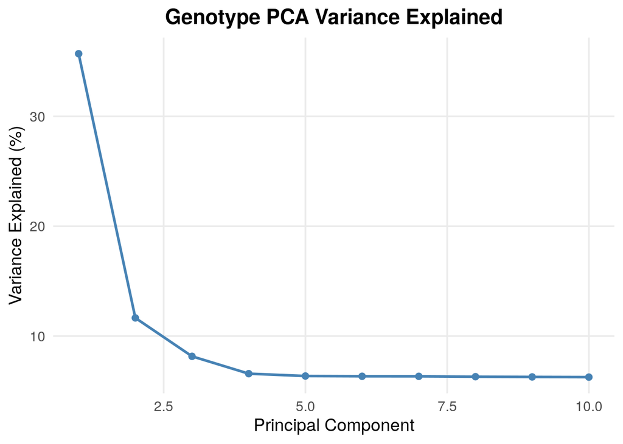

### Benchmarking

#### Table

|  | rule | n | mean_runtime_min | sd_runtime_min | mean_ram_gb | sd_ram_gb |
| --- | --- | --- | --- | --- | --- | --- |
| 1 | add_rsID | 23 | 37.388 | 1.088 | 0.035 | 0.002 |
| 2 | calc_genotype_pcs | 1 | 0.02 | 0 | 0.011 | 0 |
| 3 | check_VCF | 1 | 20.11 | 0 | 0.629 | 0 |
| 4 | exclude_SNPs | 1 | 18.445 | 0 | 0.024 | 0 |
| 5 | filter_tags | 1 | 66.245 | 0 | 0.013 | 0 |
| 6 | geno_post_report | 1 | 0.258 | 0 | 0.599 | 0 |
| 7 | get_ld_pruned_snps | 1 | 0.317 | 0 | 0.248 | 0 |
| 8 | impute_check | 23 | 1.47 | 0.659 | 0.006 | 0 |
| 9 | prune_genotypes | 1 | 0.053 | 0 | 0.334 | 0 |
| 10 | vcf_cat | 1 | 25.349 | 0 | 0.009 | 0 |

[output cut: 1 more lines]

#### Plot

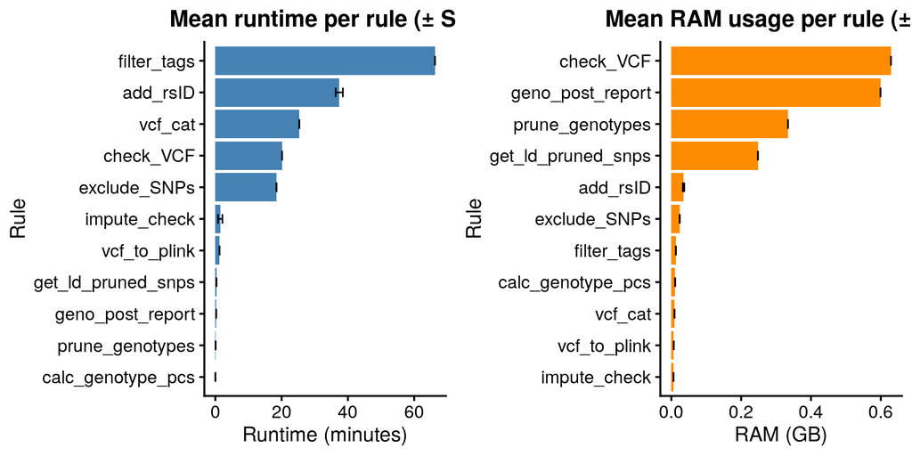